# SDP occupancy poacher-tiger

L. Marescot, A. Lyet, R. Singh, O. Gimenez

2020-05-19 03:44:25

Let’s apply the SDP to the poacher-tiger situation.

Here, we describe a decision-making process to reduce wildlife poaching and determine the optimal patrolling strategy and effort based on a system of three agents: poachers, wildlife and rangers. First, we acknowledge that rangers sometimes need to make immediate decisions despite limited information they have at hand. The SDM approach is adaptive and effective as it allows making optimal decisions despite high uncertainty, so without necessarily understanding the full behavior of the system. It consists in decomposing any problem in five main steps (Runge et al. 2011; Nichols 2012; see Figure 1) that we list here and go into details below:

- 1. An explicit formalization of the conservation objectives by stakeholders, managers and policy makers, using a mathematical function called utility/ In our case we want to minimize poacher occupancy and maximize tiger distribution. Later we can add more complexity by considering retrun on investmen (in case we can quantify the cost and benefits of patrolling) See Iadine chades 2008 on tiger conservation https://www.pnas.org/content/pnas/105/37/13936.full.pdf
- 2. A specification of competing and mutually exclusive actions (Conroy et al. 2008; Runge 2011) that we help reaching the objectives/ here as a first start, we are only interested in three patrolling strategies (random patrolling, surveillance by focusing on wildife monitoring which then deter paochers to colonize those sites, or control by focusing on patrolling sites where poachers are exppected to be). To start simple we assume that ranger don’t lear anything from random patrolling (from learning which area are unoccupied or have changed in terms of occupancies), we assume that ranger have perfect knowledge of which site are occupied. Later we relaxed those assumption and we include another action variable which is the number of patrol to be deployed (the optimal number of ranger patrol whihch need to go out each occasion accounting for the labor cost)
- 3. A sampling protocol to collect information on the state variables (here species occupancy including paochers) of the studied system and describe all the possible states configuration (Nichols and Williams 2006).
- 4. A model predicting the dynamics of the system and its response to management strategies; Here we consider a extinction colonisation dynamic model in the 4 occupancy state (Unoccupied, occupied by wildlife only, occucpied by poacher only, occupied by both) So it is spatially implicit
- 5. An evaluation of the performance of a strategy leading the system to a given state and produce management returns. This is done through an optimization algorithm. Here we use Stochastic Dynamic programming to determine the optimal strategy based on the Bellman equation (Marescot et al. 2013).

In this structured-decision making approach, rangers are modelled as utility-maximizing agents. patrolling strategy are deterministically found as solutions to the optimization problem (later we would consider stochasticity : partial controllability, structural uncertainty, monitroing uncertainty, environmental stochasticity). We modelled the distribution dynamics of poachers and wildlife, based on previous study on poachers and tiger prey interactions in Cambodia (Marescot et al. in press) and predict consequence of different patrolling strategy on the distribution map. Following the Bellman principle of optimality, future patrolling decisions will then remain optimal with respect to the results from the first patrolling decision and initial interactions between poachers and wildlife inferred by the two-species occupancy model.

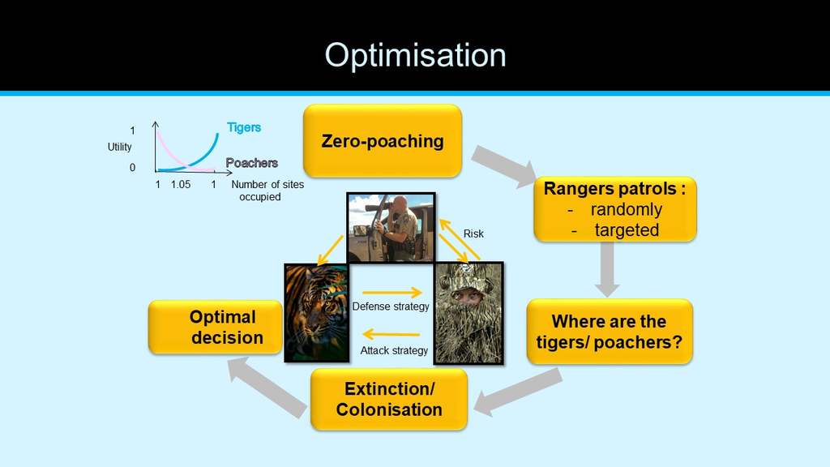

```r
rm(list=ls())
gc()
```

```
##           used (Mb) gc trigger (Mb) max used (Mb)
## Ncells  537287 28.7    1230530 65.8   609151 32.6
## Vcells 1029898  7.9    8388608 64.0  1596881 12.2
```

We first define a few parameters:

```r
K <- 20 # total number of sites
N_U <- 0:K #  number of unoccupied sites
N_TigersO <- 0:K # number of sites occupied only by tigers
N_PoachersO <- 0:K #  number of sites occupied only by poachers
N_TigersPoachers <- 0:K # number of sites occupied by both species
P <- 5 # total number of sites patrolled
```

# 1- Conservation objectives

Now let’s define the utility function:

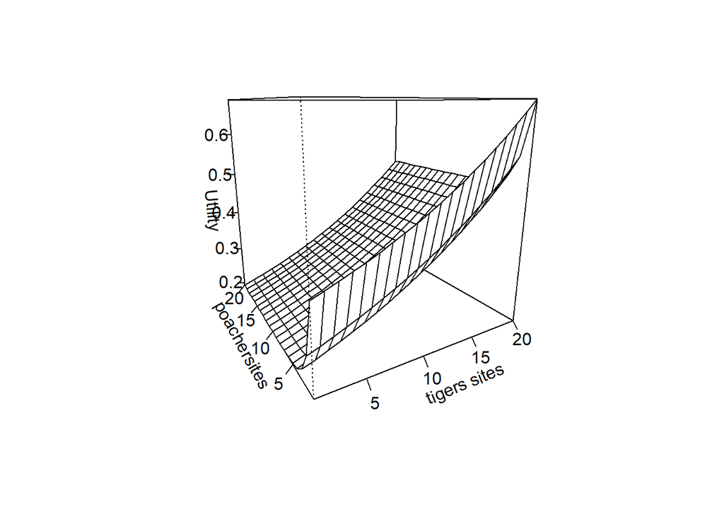

```r
Utility<-array(0,dim=c(K,K))
tigersites<-1:K
poachersites<- 1:K

for(j in 1: length(tigersites))
  for(i in 1 : length(poachersites))
      Utility[j,i] <- (1/exp(poachersites[i]) + 1/exp(1-tigersites[j]/K))/2 # this function range between 0 and 1

persp(x=tigersites,y=poachersites,Utility,theta =-30 ,phi = 15, r = sqrt(3), d = 1,ticktype="detailed",xlab="tigers sites")
```

# 2 Possibles actions on the system are:

For now, we’ll go for something a bit simple by considering only one action variable the patrolling strategy which can have three modalities: random patrol, targeting poachers, monitoring tigers. Later we consider a second variable the number of patrol to deploy (in order to determin the optimal number given the cost/benefits)

```r
action <- c("random","poachers","tigers")
# 1 random
# 2 where poachers are (management strategy driven on surveillance)
# 3 where tigers are  (management strategy driven on monitoring)
```

# 3 state variable

Let’s define the index mapping. We define here all possible landscape composition by considering site state variable which can have 4 modlaiities (unoccupied, occupied by tigers only, by poachers only by both)

```r
# Vector of sites identity
seq_states <- 0:K
# all combinations of states (number of unoccupied, occupied by tigers only, occupied by Poachers, by Tigers and poachers)
state_index <- expand.grid(seq_states,seq_states,seq_states,seq_states)
colnames(state_index)<-c("Unoccupied", "Tigers", "Poachers", "TigersPoachers")
# we pick only the rows which give a sum of K sites (landscape carrying capacity)
mask = apply(state_index,1,sum)
state_index = state_index[mask==K,]
nb_states <- dim(state_index)[1]
```

# 4 Dynamic model

We now define the function describing the distribution dynamic of the system (including consequence of actions on future states):

```r
dynamic_1 <- function (N_U,  N_Tigers, N_Poachers, N_TigersPoachers, a){

  NStages <- 4

  # A is the tiger and B the poacher

  # Occupancy in MacKenzie parameterization
  psiA = 0.3 # probability that species A is present, regardless species B
  psiB = 0.6 # probability that species B is present, regardless species A
  phi = 1.02 # species interaction factor = psiAB/(psiA*psiB) where
           # psiAB (= 1.032258*0.6*0.775 = 0.48) is the probability that both species A and B are present
  psiAB = phi * psiA * psiB
  #occupancvec<-c(1-psiA-psiB+psiAB,psiA-psiAB,psiB-psiAB,psiAB) # initial occupancy probabilities to be multiplied to the initial population vector (to be updated when adaptive management going on)?

  # transition parameters (see Table 8.7 page 245 in MacKenzie et al. 2006)

  epsilonAB = 0.1 # probability that species A and B are goin extinct given that they were both present
  epsilonA = 0.8 # probability that only species A is going Extinct given that both species are present
  epsilonB = 0.15 # probability that only species B is going Exintc given that both species are present
  etaA = 0.05  # probability that species A colonise while species B was present
  etaB = 0.25  # probability that species B colonise while species A was present
  gammaAB = 0 # probability that species A and B colonise
  gammaA = 0.1 # probability that species A colonise where species B is ABSENT
  gammaB = 0.2 # probability that species B colonise where species A is ABSENT
  nuA = 0.05 # probability that species A goes extinct where species B was absent
  nuB = 0.3 # probability that species B goes extinct where  species A was basent
  omegaAB = 0.7 # probability that species A replaced by species B
  omegaBA = 0 # probability that species B replaced by species A


  #population vector at time t which is recurrently updated in the Markov Decision Process
  popvector <- c(N_U,  N_Tigers, N_Poachers, N_TigersPoachers)

  names(popvector) <-c("Unoccupied", "Tigers only", "Poachers only", "Tigers and poachers")

  # Create a spatially implict landscape assigning for each sites the state occupied by one or both or none species from 1 to K
  # Landscape vector indicating the state of each sites can be ordered sequentially in terms of the number of sites in each ot the 4 states as there is no      # Spatial structure yet meaning that the state of neighborhood sites do not influence the state of the decision applied on on agiven site
  landscape<-c(rep(1, popvector["Unoccupied"]), rep(2, popvector["Tigers only"]), rep(3, popvector["Poachers only"]), rep(4, popvector["Tigers and poachers"]))





  if(a=="random") # random
  {

  patrol_patch <- sort(sample(K, P)) # Randomly select P patrolling plots among K
  patP<-length(which(landscape[patrol_patch]==3)) # Among the randomly patrolled patches, the number of them which are only occupied by poachers
  if(length(patP) == 0) patP<-0
  patTP<-length(which(landscape[patrol_patch]==4))  # Among the randomly patrolled patches, the number of them which occupied by both. In such case we assume poachers had time to kill the tiger before rangers arrest the poachers
  if(length(patTP) == 0) patTP<-0
  patT<-length(which(landscape[patrol_patch]==2)) # number of randomly patrolled patches where only tigers were
  # if(patT > 0) omegaAB <- omegaAB * (length(which(landscape==2)) - patT) / length(which(landscape==2)) # in that case ranger act in a preventive way avoiding those sites where tigers are to be replaced by poachers
  if(length(patT) == 0) patT<-0

  popvector["Unoccupied"] <- popvector["Unoccupied"] + patP   # We add the PatP sites to unoccupied sites at t+1
  popvector["Tigers only"] <- popvector["Tigers only"]  + patTP # We assume that rangers patrolling in patch occupied by tigers and poachers caught the poacher before the tiger. So the pacth become occupied only by tigers
  popvector["Poachers only"] <- popvector["Poachers only"]- patP #  PatP sites where poachers have beend cought before poaching a tiger
  popvector["Tigers and poachers"] <- popvector["Tigers and poachers"]- patTP #  PatTP sites where poachers have beend cought but have poached the tiger
  #popvector[2] <- popvector[2]*(1-h)
  }


  if(a=="poachers") # where poachers are
  {

    patP<-length(which(landscape== 3)) # counting patches where poachers only are
    if(length(patP) == 0) patP<-0
    patTP<-length(which(landscape== 4)) # counting patches where poachers and tigers are
    if(length(patTP) == 0) patTP<-0
    if((patP + patTP) > P) # if there is more sites occupied by poachers than patrolling stations we send the P patrols  proprotionaly to the number of patches occupied by poachers only or by both species
    {
       patP2 <- patP/(patP + patTP) * P
       patTP2 <- patTP/(patP + patTP) * P
       popvector["Unoccupied"] <- popvector["Unoccupied"]+ patP2
       popvector["Tigers only"] <- popvector["Tigers only"] + patTP2
       popvector["Poachers only"] <- popvector["Poachers only"]- patP2
       popvector["Tigers and poachers"] <- popvector["Tigers and poachers"]- patTP2


    }
    else  # otherwise they prospect everywhere there are poachers (cases where availability of patrols P > poaching pressure)
    {

      # we removed the SITES OCCUPIED BY POACHERS where rangers have been patrolling and add it to the "Unoccupied sites"
      popvector["Unoccupied"] <- popvector["Unoccupied"]+ patP
      popvector["Tigers only"] <- popvector["Tigers only"] + patTP
      popvector["Poachers only"] <- popvector["Poachers only"]- patP
      popvector["Tigers and poachers"] <- popvector["Tigers and poachers"]- patTP
  #popvector[2] <- popvector[2]*(1-h)

    }


  }


  if(a=="tigers") # where tigers are
  {

  patT<-length(which(landscape==2)) # counting patches where only tigers are
  if(length(patT) == 0) patT<-0 # TO Avoid message error
  patTP<-length(which(landscape==4)) # counting patches where poachers and tigers are
  if(length(patTP) == 0) patTP<-0

  if((patT + patTP) > P)
  {
    patT3 <- patT/(patT + patTP) * P
    patTP3 <- patTP/(patT + patTP) * P

    popvector["Unoccupied"] <- popvector["Unoccupied"]
    popvector["Tigers only"] <- popvector["Tigers only"] + patTP3
    popvector["Poachers only"] <- popvector["Poachers only"]
    popvector["Tigers and poachers"] <- popvector["Tigers and poachers"]- patTP3

    }
  else  # in case there are less sites occupied by tigers than patroling station
  {
    # first we allocate all the patroling effort to the sites occupied by tigers
      patT3 <- patT
      patTP3 <- patTP
      popvector["Unoccupied"] <- popvector["Unoccupied"]
      popvector["Tigers only"] <- popvector["Tigers only"] + patTP3
      popvector["Poachers only"] <- popvector["Poachers only"]
      popvector["Tigers and poachers"] <- popvector["Tigers and poachers"]- patTP3

  }

 if(patT > 0)
  omegaAB <- omegaAB * (patT - patT3) / patT # here we reduce the probability of a tiger site being replaced by poachers by the proportion of sites where rangers are monitoring tigers and in the same time prevent poachers to arrive (so the the replacement pobability of a site from tigers to poachers is lower). Notice that omegaAB worth 0 if there are more rangers patrols than sites occupied by poachers.
  }

  # transitoin matrix with extinction, colonisation and replacemnt processes
   dyn <- matrix(c(1-gammaA-gammaB+gammaAB,gammaA-gammaAB,gammaB-gammaAB,gammaAB,
    nuA,1-nuA-omegaAB-etaB,omegaAB,etaB,
    nuB,omegaBA,1-nuB-omegaBA-etaA,etaA,
    epsilonAB,epsilonB-epsilonAB,epsilonA-epsilonAB,1-epsilonA-epsilonB+epsilonAB), nrow = NStages, byrow = TRUE)



  next_pop <- (dyn %*% popvector)
  names(next_pop)<-names(popvector)
  return(next_pop)
}
```

Now we perform Monte Carlo simulation and generate the MDP transition matrix

```r
# Within function objects
transition <- array(0, dim = c(nb_states, nb_states, length(action)))
utility <- matrix(0, nrow = nb_states, ncol = length(action))
colnames(utility)<-action

# Generating the matrix
# Loop on all states, loop on all actions and record what you get

for (k in 1:nb_states) {

  # Get number of individuals in packs and dispersers
  i <- state_index[k,1]
  j <- state_index[k,2]
  r <- state_index[k,3]
  v <- state_index[k,4]

  counter<-0
  # Try all actions
  for (h in unique(action)) {
    counter <- counter + 1
    next_pop <- dynamic_1(i, j, r, v, h)

    utility[k,counter] <-1/exp(next_pop[3]+next_pop[4]) + 1/exp(1-(next_pop[2]+next_pop[4])/K)

    next_pop[1] <- min(floor(next_pop[1]), K)
    next_pop[3] <- min(floor(next_pop[3]), K)
    next_pop[2] <- min(floor(next_pop[2]), K)
    next_pop[4] <- K- next_pop[1]- next_pop[2] -next_pop[3]
    # quick qnd dirty to make sure the population stay at the total number of sites as the system can not expand
    next_pop<-sapply(next_pop,function(x) max(x,0))
    next_pop<-sapply(next_pop,function(x) min(x,K))
    if(sum(next_pop) > K) next_pop[next_pop==max(next_pop)] <- next_pop[next_pop==max(next_pop)]- sum(next_pop) + K
    if(sum(next_pop) < K) next_pop[4] <- K- next_pop[2]- next_pop[3] -next_pop[1]



    nextk<-which(state_index[,1] == next_pop[1] & state_index[,2] == next_pop[2] & state_index[,3] ==    next_pop[3] & state_index[,4] == next_pop[4])

    #vERY EASY AS WE ARE IN DETERMINISTIC SCENARION SO THE TRASITION MATRIX IS 0-1
    transition[k,nextk,counter]<- 1

  }
}
```

# 5 Run the SDP and plot optimal solution

In Stochastic Dynamic Programming, the optimal solution is state-dependent but as the algorithm calculate the optimal trajecotry it leads at some point to a solution which is time-independent The figure summarize at equilirbium the optimal which is the best strategy (the most likely to reach the objecitves) for any state combination, i.e any landscape composition : number of sites occupied by tigers only (x axis), poachers only (y axis), both (panels)) Red is for random patroling, yellow is patrolling where tigers are, orange is patroling where poachers are.

```r
library(MDPtoolbox)
require(lattice)
mdp_check(transition,utility)
```

```
## [1] ""
```

```r
S <- mdp_value_iteration(transition, utility, discount = 0.9, epsilon = 0.001)
```

```
## [1] "MDP Toolbox: iterations stopped, epsilon-optimal policy found"
```

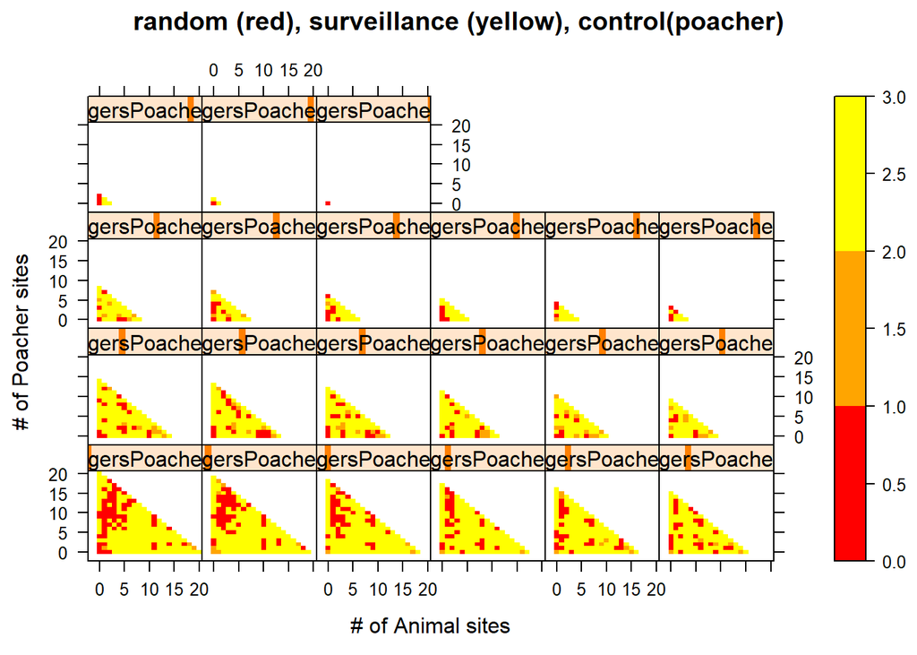

```r
state_index<-as.data.frame(state_index)
state_index$policy<-S$policy
levelplot(policy ~ Tigers * Poachers | TigersPoachers, data=state_index, cut=3, at=c(0,1,2,3), region=TRUE, xlab="# of Animal sites",ylab="# of Poacher sites", col.regions= c("red","orange","yellow"), main="random (red), surveillance (yellow), control(poacher)")
```

# 6 checking that we are reaching the objectives

Simulating forward by applying the optimal strategy to the current study areas of PPWS and PWS in Cambodia and predict over 50 years the composition of the landscape with respect to the conservation objectives (the number of sites occupied by poachers, and the number of sites occupied by wildlife). We compared this figure to another panels of graph showing the temporal changes in the number of site occupied by poachers and wildlife when a fixed strategy of either patrolling randomly, or based on monitoring only, or on surveillance only, is conducted regarldess of the states of the system. Finally we plotted the cumulated value of utility wether the optimal or non-optimal stratgey is being applied.

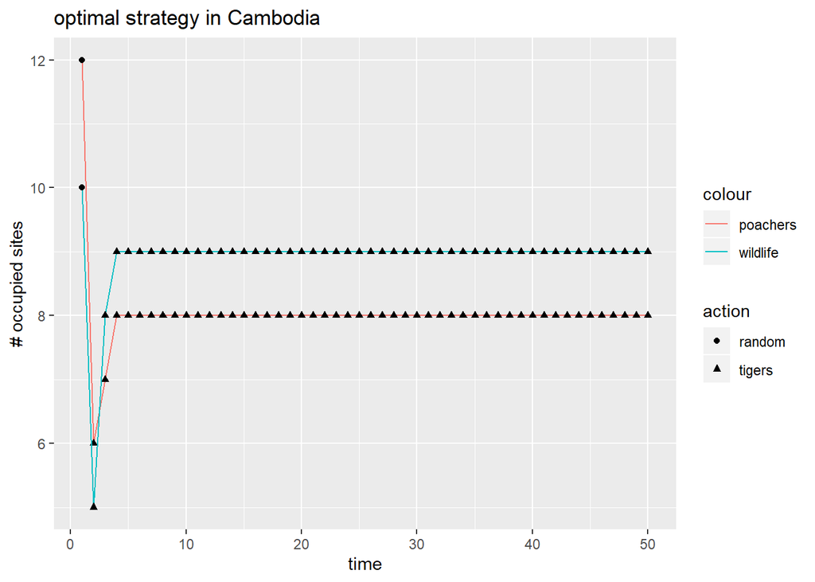

```r
 library(tidyverse)

#let's define the utility as a function

Objectives<-function(i, j, K, S, P) # i, the number of poachers sites, j the number of tiger sites, K the total number of sites, S the number of success sites (that is from later when we include cos and benefits in the funciton)
{

     Utility <- (1/exp(i) + 1/exp(1-j/(K)))/2
  return(Utility)
}


#here we put the initial occupancy probability

 OW <- round(0.06*K)
 OP <- round(0.13*K)
 PW <- round(0.45*K)
 U  <- round(0.37*K)


 tps<-50

 reward<-NULL
 reward[1]<-0
 nothing<-NULL
 nothing[1]<-0

# initialisation of the vector with cumulated Utilities starting with the value when 0 rangers are deployed and the current study areas is as descirbed in Marescot et al. (Under review)
utility_init <-  Objectives((OP + PW), (OW+PW), K, 0, 0)

#names(siteocc)<-c("site", "abundance", "action", "strategy", "time", "utility")

vec<-c(U,OP,OW,PW)
siteocc<-c(vec,"random", "optimal",1, utility_init,0)

# vector of site composition for the non optimal strtategies
vec1<-vec2<-vec3<-vec4 <-vec
# here we create the dataframe whihc will hold all the information necessary for the ggplot figure
names(siteocc)<-c("U", "OP","OW","WP", "action", "strategy", "time", "utility_function", "simulation")
siteocc<-rbind(siteocc, c(vec,"nothing", "not-optimal",1, utility_init, 0))
siteocc<-rbind(siteocc, c(vec,"always tiger sites", "not-optimal",1, utility_init, 0))
siteocc<-rbind(siteocc, c(vec,"always poacher sites", "not-optimal",1, utility_init, 0))
siteocc<-rbind(siteocc, c(vec,"always random", "not-optimal",1, utility_init, 0))

# intitialize vector of sitecomposition under given strategies and utility value according to which strategy is being applied (fixed or optimal)
reward<-NULL
reward[1]<-0
nothing<-NULL
nothing[1]<-0
alwaystiger<-NULL
alwaystiger[1]<-0
alwayspoachers<-NULL
alwayspoachers[1]<-0
alwaysrandom<-NULL
alwaysrandom[1]<-0

  #MCiter<-100 when stochastic
  MCiter<-1
  s<-1
  moysite<-matrix(0, nrow=MCiter, ncol=5)
  for(t in 2:tps)
  {

  # record the site compoisiton under optimal trajectories
  j <-  max(0,min(vec[2],K)) # occupied by poacher only
  r <-  max(0,min(vec[3],K)) # occupied by tiger only
  v <-  max(0,min(vec[4],K)) # occupied by tiger and poachers
  i <-  max(0,K - vec[4] - vec[2] - vec[3]) # unoccupied (subsrtacted from other configuration to make sure the study area stays bounded at K sites)

  # record the site composition when no action is being made
  j1 <-  max(0,min(vec1[2],K))
  r1 <-  max(0,min(vec1[3],K))
  v1 <-  max(0,min(vec1[4],K))
  i1 <-  max(0,K - vec1[4] - vec1[2] - vec1[3])
   # record the site composition when only monitoring occur
  j2 <-  max(0,min(vec2[2],K))
  r2 <-  max(0,min(vec2[3],K))
  v2 <-  max(0,min(vec2[4],K))
  i2 <-  max(0,K - vec2[4] - vec2[2] - vec2[3])

   # record the site composition when there is only surveillance
  j3 <-  max(0,min(vec3[2],K))
  r3 <-  max(0,min(vec3[3],K))
  v3 <-  max(0,min(vec3[4],K))
  i3 <-  max(0,K - vec3[4] - vec3[2] - vec3[3])

   # record the site composition when rangers always patrol randomly
  j4 <-  max(0,min(vec4[2],K))
  r4 <-  max(0,min(vec4[3],K))
  v4 <-  max(0,min(vec4[4],K))
  i4 <-  max(0,K - vec4[4] - vec4[2] - vec4[3])

  # determine the position of the site composition of the study area at time t in the dataframe of all state combinations
  k<-which(state_index[,1]==i & state_index[,2]==j & state_index[,3]==r & state_index[,4]==v)
  st_index<-state_index$policy[k]

 # uncommment this section if you want to use montecarlo simulation to account for the strocastic process in the random patrolling strategy
  #if(action[h]=="random")
  # {
  #   for(s in 1:MCiter)
  #   {  model<- dynamic_1(i, j, r, v, action[h])
  #      moysite[s,1:4]<-model[[1]]
  #      moysite[s,5]<-model[[2]]
  #
  #   }
  #      next_site <- apply(moysite, 2, mean)
  #      next_site <- list(next_site[1:4], next_site[5])
  # }
  #else
    next_site<-dynamic_1(i, j, r, v, action[st_index]) # here the composition of the study area given after optimal stratgey as been applied and biological and poaching process occured given that it was at a certain sites were at state of occupancy

  #indice<-which(strategy==action[h])
  # composition of the study area at the next step when no action is undertaken only biologcial and poaching processes occured
  next_sitenoaction<-dynamic_1(i1, j1, r1, v1, 1)

  # composition of the study area at the next step when only monitoring wildlife is considered
  next_sitetiger<-dynamic_1(i2, j2, r2, v2,"tigers")

  # composition of the study area at the next step when only surveillance against poaching is advocated
  next_sitepoacher<-dynamic_1(i3, j3, r3, v3,"poachers")

  # composition of the study area at the next step when patrolling is always random

  next_siterandom<-dynamic_1(i4, j4, r4, v4,"random")

  # discritizing and bouding the vector of site composition for the next step so the markov decision chain can proceed and assigned an optimal strategy to the future state
  vec <- floor(unlist(next_site)) # DOING NOTHING
  vec<-sapply(vec,function(x) max(x,0) )
  vec<-sapply(vec,function(x) min(x,K) )
  vec[1]<- max(0, K - vec[4] - vec[2] - vec[3])

  if(sum(vec) > K) vec[vec==max(vec)] <- vec[vec==max(vec)]- sum(vec) + K
  if(sum(vec) < K) vec[1] <- K- vec[2]- vec[3] -vec[4]


  # discritizing the vector of site composition for the next step making sure it bounds to K, so the markov chain can determine the next state of the system to which we will apply non-optimal fixed strategy
  vec1  <- floor(unlist(next_sitenoaction))
  vec1[1]<-max(K - vec1[4] - vec1[2] - vec1[3])
  vec1<-sapply(vec1,function(x) max(x,0))
  vec1<-sapply(vec1,function(x) min(x,K))
  if(sum(vec1) > K) vec1[vec1==max(vec1)] <- vec1[vec1==max(vec1)]- sum(vec1) + K
  if(sum(vec1) < K) vec1[1] <- K- vec1[2]- vec1[3] -vec1[4]


  vec2  <- floor(unlist(next_sitetiger))
  vec2[1]<-max(0,K - vec2[4] - vec2[2] - vec2[3])
  vec2<-sapply(vec2,function(x) max(x,0))
  vec2<-sapply(vec2,function(x) min(x,K))
  if(sum(vec2) > K) vec2[vec2==max(vec2)] <- vec2[vec2==max(vec2)]- sum(vec2) + K
  if(sum(vec2) < K) vec2[1] <- K- vec2[2]- vec2[3] -vec2[4]


  vec3  <- floor(unlist(next_sitepoacher))
  vec3[1]<- max(0,K - vec3[4] - vec3[2] - vec3[3])
  vec3<-sapply(vec3,function(x) max(x,0))
  vec3<-sapply(vec3,function(x) min(x,K))
  if(sum(vec3) > K) vec3[vec3==max(vec3)] <- vec3[vec3==max(vec3)]- sum(vec3) + K
  if(sum(vec3) < K) vec3[1] <- K- vec3[2]- vec3[3] -vec3[4]


  vec4  <- floor(unlist(next_siterandom))
  vec4[1]<- max(0,K - vec4[4] - vec4[2] - vec4[3])
  vec4<-sapply(vec4, function(x) max(x,0))
  vec4<-sapply(vec4, function(x) min(x,K))
  if(sum(vec4) > K) vec4[vec4==max(vec4)] <- vec4[vec4==max(vec4)]- sum(vec4) + K
  if(sum(vec4) < K) vec4[1] <- K- vec4[2]- vec4[3] -vec4[4]


  reward[t]<- reward[t-1] + utility[k,st_index] #Objectives((vec[2]+vec[4]), (vec[3]+vec[4]), K, next_site[[2]], P)
  nothing[t]<- nothing[t-1] + Objectives((vec1[2]+vec1[4]), (vec1[3]+vec1[4]), K,  0, 0)
  alwaystiger[t]<- alwaystiger[t-1] + Objectives((vec2[2]+vec2[4]), (vec2[3]+vec2[4]), K,  0, 0)
  alwayspoachers[t]<- alwayspoachers[t-1] + Objectives((vec3[2]+vec3[4]), (vec3[3]+vec3[4]), K,  0, 0)
  alwaysrandom[t]<- alwaysrandom[t-1] + Objectives((vec4[2]+vec4[4]), (vec4[3]+vec4[4]), K,  0, 0)

  siteocc <- rbind(siteocc, c(vec, as.character(action[st_index]), "optimal",t, reward[t], s),c(vec1, "nothing", "not-optimal",t, nothing[t], s), c(vec2, "always tiger sites", "not-optimal",t, alwaystiger[t], s), c(vec3, "always poacher sites", "not-optimal",t, alwayspoachers[t], s), c(vec4, "always random", "not-optimal",t, alwaysrandom[t], s))

  }


  siteocc<-as.data.frame(siteocc)
  siteocc$U<-as.numeric(as.character(siteocc$U))
  siteocc$OW<-as.numeric(as.character(siteocc$OW))
  siteocc$OP<-as.numeric(as.character(siteocc$OP))
  siteocc$WP<-as.numeric(as.character(siteocc$WP))
  siteocc$time<-as.numeric(as.character(siteocc$time))
  siteocc$utility_function<-as.numeric(as.character(siteocc$utility_function))
  siteocc$simulation<-as.numeric(as.character(siteocc$simulation))

  optimsite<- siteocc %>% filter(strategy=='optimal')  %>% mutate(Npoacher=as.numeric(as.character(OP)) +   as.numeric(as.character(WP)), Nwildlife=as.numeric(as.character(OW)) + as.numeric(as.character(WP))) %>%   group_by(time) %>% mutate(Npoacher=mean(Npoacher), Nwildlife=mean(Nwildlife),     utility_function=mean(utility_function))

   optimsite  %>%
    ggplot() +
  #aes(x = as.numeric(time), y = Npoacher) +
  geom_line(aes(x = as.numeric(as.character(time)), y = Npoacher, color="poachers")) +
  geom_point(aes(x = as.numeric(as.character(time)), y = Npoacher, shape=action))+
  geom_line(aes(x = as.numeric(as.character(time)), y = Nwildlife, color="wildlife")) +
  geom_point(aes(x = as.numeric(as.character(time)), y = Nwildlife, shape=action))+
  xlab("time") + ylab("# occupied sites") + ggtitle("optimal strategy in Cambodia")
```

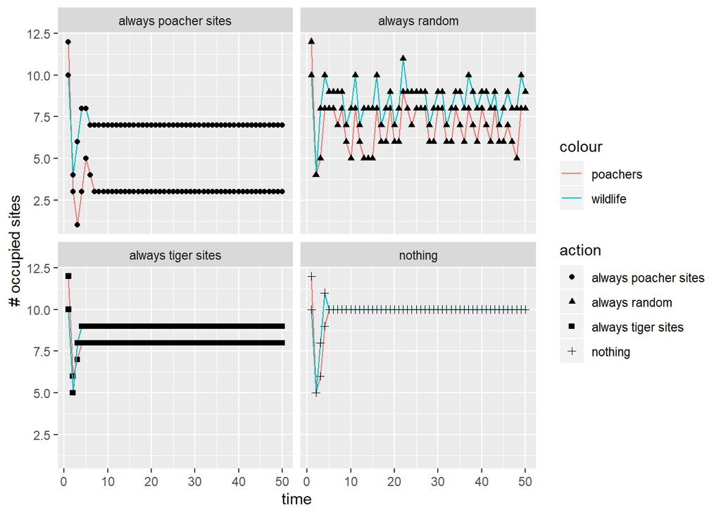

```r
  siteocc %>% filter(strategy=='not-optimal') %>% mutate( Npoacher=as.numeric(OP) + as.numeric(WP),  Nwildlife=as.numeric(OW) + as.numeric(WP))     %>%
  ggplot() +
  #aes(x = as.numeric(time), y = Npoacher) +
  geom_line(aes(x = as.numeric(as.character(time)), y = Npoacher, color="poachers")) +
  geom_point(aes(x = as.numeric(as.character(time)), y = Npoacher, shape=action))+
  geom_line(aes(x = as.numeric(as.character(time)), y = Nwildlife, color="wildlife")) +
  geom_point(aes(x = as.numeric(as.character(time)), y = Nwildlife, shape=action))+
  facet_wrap(vars(action))+
  xlab("time") + ylab("# occupied sites")
```

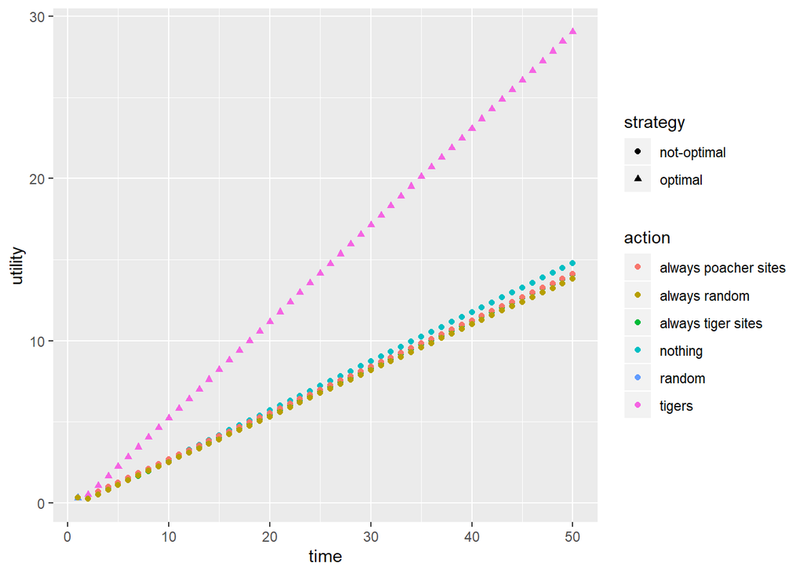

```r
  siteocc %>%
  ggplot()  +
  aes(x = as.numeric(as.character(time)), y = as.numeric(as.character(utility_function))) +
 # geom_line(aes(color=strategy)) +
  geom_point(aes(x = as.numeric(as.character(time)), y = as.numeric(as.character(utility_function)), shape = strategy, color=action)) +
  xlab("time") + ylab("utility")
```

```r
  save(S, reward, siteocc, file=  "./optimal_U1_NOcostPatrol.txt")
```